# Three arm simulation

Variations on a theme

Keaven M. Anderson

2023-01-21

```r
library(dplyr)
library(tibble)
library(gt)
library(survival)
library(mvtnorm)
library(gsDesign)
library(gsDesign2)
library(ggplot2)
library(cowplot)
library(simtrial)
```

# Introduction

This is to demonstrate a simulation with more than 2 arms and with different dropout rates in each arm using `simtrial::simPWSurv()`. The simplest case is for 3 arms and a single stratum. There are 3 parts to document:

1. Assumptions for enrollment and time-to-event distribution by treatment group.
2. Generating data for multiple treatment groups including differential censoring rates.
3. Testing for advantage of 2 experimental treatments over control using different multiplicity strategies.

```r
scen <- 1 # Select scenario to simulate
```

# Assumptions for example

We lay out assumptions. We assume a single stratum with blocks of 6 (2:2:2) randomization (Control:Ex1:Ex2). We assume a constant enrollment rate until the targeted sample size (‘n’) is reached.

```r
# 3 treatment groups
tx <- c("Control", "Ex1", "Ex2")
# Blocks of 5 with 1:2:2 randomization
block <- c("Control", "Control", "Ex1", "Ex1", "Ex2", "Ex2")
```

For enrollment, we assume ramp-up for 4 months followed by 10 months of study state enrollment for a total enrollment duration of 14 months.

```r
enroll_rate <- tibble(stratum = "All", duration = c(2, 2, 10), rate = c(3, 6, 9))
enroll_duration <- sum(enroll_rate$duration)
```

Now we set failure rates for each treatment group for 6 different scenarios. We can have different piecewise exponential distribution rates for each treatment group.

## Failure rate scenarios

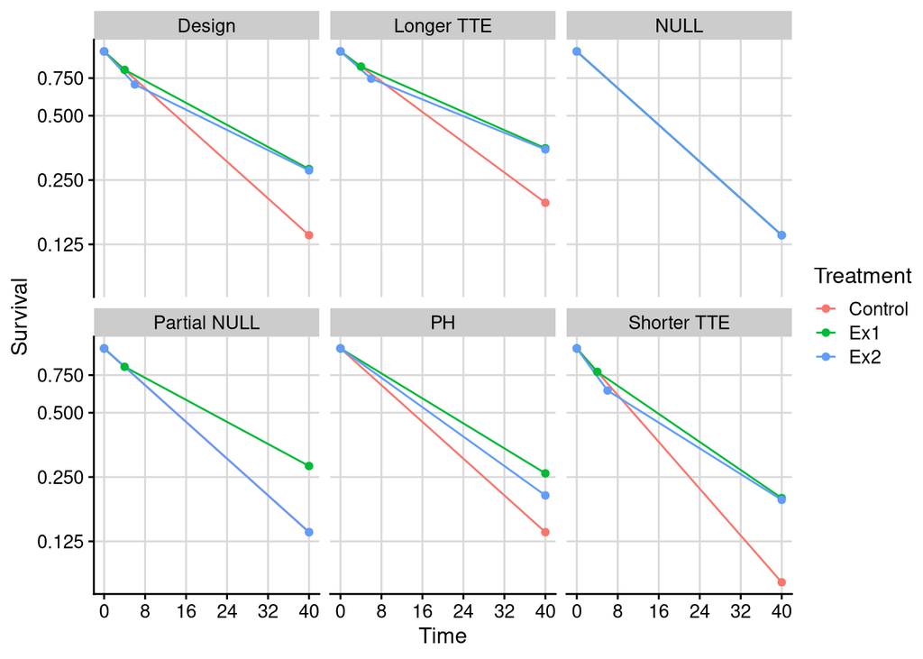